# Contexto para analisis exploratorio

Las ventas en linea son un campo enorme de analisis, ya que estas generan una cantidad de datos por cada compra, los cuales podemos usar para predecir inventario, analizar campañas de publicidad, identificar tendencias de ventas, predecir ventas de un producto nuevo, etc. Por todo lo anterior, he decidido realizar este ejercicio para poder mostrar la manera en la que podemos aportar valor a multiples e-commerce

#### Objetivo: Poder predecir las ventas de una tienda por un periodo de una semana

El dataset que usaremos para este ejemplo ha sido tomado de kaggle y modificado a manera que podamos entender de una manera mas intuitiva el comportamiento de las ventas, este dataset originalmente pertenece a las ventas de Walmart

### Primero debemos importar las librerias que se usaran en este ejercicio

```python
import numpy as np      # To use np.arrays
import pandas as pd     # To use dataframes
from pandas.plotting import autocorrelation_plot as auto_corr

# To plot
import matplotlib.pyplot as plt
%matplotlib inline
import matplotlib as mpl
import seaborn as sns

#For date-time
import math
from datetime import datetime
from datetime import timedelta

# Another imports if needs
import itertools
import statsmodels.api as sm
import statsmodels.tsa.api as smt
import statsmodels.formula.api as smf
```

```python
pd.options.display.max_columns=100 # to see columns
```

```python
df_store = pd.read_csv('/Users/alexcastillo/Desktop/VisualCode/Portafolio/E-commerce/DataWalmart/stores.csv') #store data
```

```python
df_train = pd.read_csv('/Users/alexcastillo/Desktop/VisualCode/Portafolio/E-commerce/DataWalmart/train.csv') # train set
```

```python
df_features = pd.read_csv('/Users/alexcastillo/Desktop/VisualCode/Portafolio/E-commerce/DataWalmart/features.csv') #external information
```

## Primero veremos los datos para conocer que tenemos

```python
df_store.head()
```

|  | Store | Type | Size |
| --- | --- | --- | --- |
| 0 | 1 | A | 151315 |
| 1 | 2 | A | 202307 |
| 2 | 3 | B | 37392 |
| 3 | 4 | A | 205863 |
| 4 | 5 | B | 34875 |

```python
df_train.head()
```

|  | Store | Dept | Date | Weekly_Sales | IsHoliday |
| --- | --- | --- | --- | --- | --- |
| 0 | 1 | 1 | 2010-02-05 | 24924.50 | False |
| 1 | 1 | 1 | 2010-02-12 | 46039.49 | True |
| 2 | 1 | 1 | 2010-02-19 | 41595.55 | False |
| 3 | 1 | 1 | 2010-02-26 | 19403.54 | False |
| 4 | 1 | 1 | 2010-03-05 | 21827.90 | False |

```python
df_features.head()
```

|  | Store | Date | Temperature | Fuel_Price | MarkDown1 | MarkDown2 | MarkDown3 | MarkDown4 | MarkDown5 | CPI | Unemployment | IsHoliday |
| --- | --- | --- | --- | --- | --- | --- | --- | --- | --- | --- | --- | --- |
| 0 | 1 | 2010-02-05 | 42.31 | 2.572 | NaN | NaN | NaN | NaN | NaN | 211.096358 | 8.106 | False |
| 1 | 1 | 2010-02-12 | 38.51 | 2.548 | NaN | NaN | NaN | NaN | NaN | 211.242170 | 8.106 | True |
| 2 | 1 | 2010-02-19 | 39.93 | 2.514 | NaN | NaN | NaN | NaN | NaN | 211.289143 | 8.106 | False |
| 3 | 1 | 2010-02-26 | 46.63 | 2.561 | NaN | NaN | NaN | NaN | NaN | 211.319643 | 8.106 | False |
| 4 | 1 | 2010-03-05 | 46.50 | 2.625 | NaN | NaN | NaN | NaN | NaN | 211.350143 | 8.106 | False |

```python
# Vamos a combinar los data frames
df = df_train.merge(df_features, on=['Store', 'Date'], how='inner').merge(df_store, on=['Store'], how='inner')
df.head(5)
```

|  | Store | Dept | Date | Weekly_Sales | IsHoliday_x | Temperature | Fuel_Price | MarkDown1 | MarkDown2 | MarkDown3 | MarkDown4 | MarkDown5 | CPI | Unemployment | IsHoliday_y | Type | Size |
| --- | --- | --- | --- | --- | --- | --- | --- | --- | --- | --- | --- | --- | --- | --- | --- | --- | --- |
| 0 | 1 | 1 | 2010-02-05 | 24924.50 | False | 42.31 | 2.572 | NaN | NaN | NaN | NaN | NaN | 211.096358 | 8.106 | False | A | 151315 |
| 1 | 1 | 1 | 2010-02-12 | 46039.49 | True | 38.51 | 2.548 | NaN | NaN | NaN | NaN | NaN | 211.242170 | 8.106 | True | A | 151315 |
| 2 | 1 | 1 | 2010-02-19 | 41595.55 | False | 39.93 | 2.514 | NaN | NaN | NaN | NaN | NaN | 211.289143 | 8.106 | False | A | 151315 |
| 3 | 1 | 1 | 2010-02-26 | 19403.54 | False | 46.63 | 2.561 | NaN | NaN | NaN | NaN | NaN | 211.319643 | 8.106 | False | A | 151315 |
| 4 | 1 | 1 | 2010-03-05 | 21827.90 | False | 46.50 | 2.625 | NaN | NaN | NaN | NaN | NaN | 211.350143 | 8.106 | False | A | 151315 |

```python
df.drop(['IsHoliday_y'], axis=1,inplace=True) # Eliminamos la columna duplicada
df.rename(columns={'IsHoliday_x':'IsHoliday'},inplace=True) #Cambiamos el nombre de la columna quedante
```

```python
#Checamos nuestro resultado
df.head()
```

|  | Store | Dept | Date | Weekly_Sales | IsHoliday | Temperature | Fuel_Price | MarkDown1 | MarkDown2 | MarkDown3 | MarkDown4 | MarkDown5 | CPI | Unemployment | Type | Size |
| --- | --- | --- | --- | --- | --- | --- | --- | --- | --- | --- | --- | --- | --- | --- | --- | --- |
| 0 | 1 | 1 | 2010-02-05 | 24924.50 | False | 42.31 | 2.572 | NaN | NaN | NaN | NaN | NaN | 211.096358 | 8.106 | A | 151315 |
| 1 | 1 | 1 | 2010-02-12 | 46039.49 | True | 38.51 | 2.548 | NaN | NaN | NaN | NaN | NaN | 211.242170 | 8.106 | A | 151315 |
| 2 | 1 | 1 | 2010-02-19 | 41595.55 | False | 39.93 | 2.514 | NaN | NaN | NaN | NaN | NaN | 211.289143 | 8.106 | A | 151315 |
| 3 | 1 | 1 | 2010-02-26 | 19403.54 | False | 46.63 | 2.561 | NaN | NaN | NaN | NaN | NaN | 211.319643 | 8.106 | A | 151315 |
| 4 | 1 | 1 | 2010-03-05 | 21827.90 | False | 46.50 | 2.625 | NaN | NaN | NaN | NaN | NaN | 211.350143 | 8.106 | A | 151315 |

```python
df.shape
```

```
(421570, 16)
```

### Numeros de tiendas y departamentos

```python
df['Store'].nunique() # Numero de valores diferentes en la columna STORE, o sea tenemos 45 tiendas existentes (number of different values )
```

```
45
```

```python
df['Dept'].nunique() # Numero de departamentos diferentes / number of different values
```

```
81
```

Ahora ya sabemos que tenemos 45 tiendas y 81 departamentos, podemos revisar el promedio para revisar si existe algun comportamiento raro

```python
Tiendas_y_departamentos = pd.pivot_table(df, index='Store', columns='Dept',
                                  values='Weekly_Sales', aggfunc=np.mean)
display(Tiendas_y_departamentos)
```

| Dept Store | 1 | 2 | 3 | 4 | 5 | 6 | 7 | 8 | 9 | 10 | 11 | 12 | 13 | 14 | 16 | 17 | 18 | 19 | 20 | 21 | 22 | 23 | 24 | 25 | 26 | 27 | 28 | 29 | 30 | … |
| --- | --- | --- | --- | --- | --- | --- | --- | --- | --- | --- | --- | --- | --- | --- | --- | --- | --- | --- | --- | --- | --- | --- | --- | --- | --- | --- | --- | --- | --- | --- |
| 1 | 22513.322937 | 46102.090420 | 13150.478042 | 36964.154476 | 24257.941119 | 4801.780140 | 24566.487413 | 35718.257622 | 28062.052238 | 31033.386364 | 24919.270629 | 10566.545315 | 38692.880490 | 15268.550909 | 24151.061329 | 9196.557902 | 7765.304425 | 1259.018531 | 4091.571538 | 7808.450559 | 8052.076154 | 21623.184685 | 6187.389720 | 10152.336783 | 6767.997273 | 1374.649650 | 593.113986 | 4651.040210 | 3415.295035 | … |
| 2 | 30777.980769 | 65912.922517 | 17476.563357 | 45607.666573 | 30555.315315 | 6808.382517 | 40477.837063 | 58707.369441 | 34375.864476 | 38845.854476 | 23382.686154 | 7735.946294 | 46117.959231 | 21314.132937 | 27005.179650 | 13790.854196 | 11687.563009 | 4053.439930 | 5748.619441 | 9910.939860 | 12923.013846 | 29170.616573 | 8309.564545 | 15299.508392 | 9347.725105 | 1837.954615 | 798.913217 | 7111.482657 | 4981.155385 | … |
| 3 | 7328.621049 | 16841.775664 | 5509.300769 | 8434.186503 | 11695.366573 | 2012.411818 | 10044.341608 | 8310.254196 | 9062.007692 | 10871.944126 | 8774.928042 | 2383.603007 | 11363.061678 | 4626.649021 | 7871.568322 | 2634.199650 | 2960.677739 | 731.313147 | 1682.199231 | 1244.529650 | 3101.769860 | 10913.330070 | 2763.627343 | 4260.447972 | 2850.050839 | 500.193636 | 166.870070 | 1517.404056 | 1243.926993 | … |
| 4 | 36979.940070 | 93639.315385 | 19012.491678 | 56603.400140 | 45668.406783 | 8241.777692 | 50728.151399 | 62949.723776 | 34437.170979 | 37269.667413 | 27145.836643 | 8141.910979 | 69596.447343 | 28567.509441 | 21270.153007 | 15815.878042 | 13146.543790 | 3038.317762 | 8888.302867 | 8865.273147 | 17289.916294 | 46234.012867 | 10875.301189 | 15640.748531 | 18429.759930 | 2579.906154 | 916.232238 | 9472.121189 | 7683.686783 | … |
| 5 | 9774.553077 | 12317.953287 | 4101.085175 | 9860.806783 | 6699.202238 | 1191.057622 | 6124.484336 | 13735.709441 | 7919.805944 | 9783.395385 | 7389.049441 | 2515.347273 | 11242.656084 | 3697.422378 | 7717.567622 | 2396.781329 | 2185.893000 | 46.327368 | 1220.832797 | 1316.414615 | 2430.053986 | 6141.862727 | 1480.232797 | 2685.578182 | 1782.209510 | 377.289161 | 203.282378 | 1343.724895 | 857.152448 | … |
| 6 | 23867.553776 | 50269.437273 | 16806.638811 | 34187.366503 | 34465.307622 | 7225.566643 | 34526.870420 | 47577.719790 | 48271.060140 | 47436.477902 | 21882.119091 | 6683.218671 | 37746.931399 | 25583.741399 | 28204.007552 | 16296.992448 | 11500.897168 | 2585.304755 | 9299.858601 | 9398.605455 | 18833.150909 | 30538.913776 | 6789.380909 | 13777.691399 | 9098.639371 | 1798.563846 | 578.535455 | 6858.093916 | 5020.268182 | … |
| 7 | 9542.801259 | 22603.690769 | 8633.536923 | 14950.518601 | 13860.350490 | 6329.928811 | 10925.757063 | 13970.619371 | 29722.736084 | 21136.560280 | 15362.294126 | 5674.272517 | 14916.528392 | 10108.054476 | 13788.448881 | 5568.405385 | 4255.952842 | 468.264615 | 3127.778531 | 1885.265175 | 6814.387692 | 14138.214266 | 2555.765245 | 5219.990280 | 1948.915804 | 644.632867 | 190.669510 | 1363.612448 | 1103.170979 | … |
| 8 | 14789.827343 | 35729.821748 | 10683.305105 | 21089.309301 | 19838.849231 | 3395.425455 | 20268.743776 | 26438.524336 | 11792.661678 | 20666.433776 | 18628.061469 | 7132.540769 | 25257.586434 | 10771.757343 | 16500.473776 | 7494.439021 | 6304.318017 | 1065.873916 | 3771.235734 | 4685.762378 | 7138.113287 | 14693.072587 | 4429.390909 | 6801.176503 | 6156.060979 | 923.820699 | 316.680839 | 2915.290070 | 2335.261818 | … |
| 9 | 11846.558252 | 24969.477413 | 7497.356783 | 17165.947762 | 19282.746014 | 2806.416364 | 13826.694336 | 21424.470699 | 13196.569720 | 12810.480350 | 14721.070979 | 6466.066014 | 22133.400629 | 7369.519580 | 12013.562797 | 4951.019091 | 4100.968364 | 1444.764755 | 2567.934895 | 3614.488741 | 4941.852587 | 11000.589720 | 2477.753986 | 5204.926434 | 4032.770769 | 703.237413 | 246.345664 | 1919.389231 | 1601.397972 | … |
| 10 | 39925.138951 | 109795.291469 | 32086.181469 | 48579.826364 | 58373.460280 | 10556.550769 | 58964.715664 | 86739.846643 | 64436.722517 | 48108.063497 | 32911.815385 | 9243.158531 | 62799.067483 | 40044.637762 | 30273.874755 | 27206.583357 | 18255.933810 | 3077.088462 | 15551.453776 | 9678.942098 | 25618.934126 | 65729.846573 | 15179.222937 | 21141.616294 | 17197.121678 | 4361.426503 | 1327.127273 | 15703.823427 | 11490.118951 | … |
| 11 | 18860.911958 | 57114.326224 | 17628.778671 | 28837.744545 | 36663.363916 | 5925.281678 | 34844.108462 | 34415.449580 | 19056.162168 | 23449.992727 | 18045.040210 | 4293.703497 | 41228.146154 | 24644.513077 | 15371.136434 | 13373.138322 | 11033.074286 | 1435.587073 | 9634.961958 | 7571.596573 | 15500.204266 | 34322.483497 | 8592.320839 | 11419.655385 | 11332.874685 | 2203.137483 | 912.481958 | 9225.784755 | 6765.267762 | … |
| 12 | 17330.087622 | 74494.846224 | 17535.251678 | 26673.788182 | 27756.204615 | 6741.174895 | 34242.449161 | 42229.665035 | 19553.030490 | 17975.211119 | 17789.776993 | 4878.279650 | 46974.984965 | 19719.239650 | 7579.577552 | 11666.809161 | 9893.141316 | 2949.156084 | 6558.721329 | 4225.581189 | 10085.826154 | 38809.980769 | 11182.713077 | 20129.949790 | 13748.230000 | 2017.176364 | 880.158881 | 6973.458392 | 5950.700140 | … |
| 13 | 47020.455455 | 76339.960000 | 26116.623706 | 42563.275455 | 56786.934755 | 7886.826993 | 59896.738601 | 36238.867972 | 41236.445175 | 29431.879231 | 21280.789790 | 7926.647483 | 47698.818182 | 26378.644196 | 22255.482098 | 17713.297902 | 17013.656410 | 3979.954056 | 8781.979231 | 9117.091259 | 16476.987692 | 30216.258741 | 10426.793077 | 15181.840140 | 12958.888392 | 2685.000140 | 1410.386713 | 6152.025944 | 4520.360559 | … |
| 14 | 30611.783357 | 77704.857972 | 19418.273986 | 52936.323287 | 33468.325035 | 7016.829790 | 53256.150280 | 53425.359860 | 22025.603497 | 20165.667133 | 20359.693077 | 5467.919301 | 60009.833706 | 24775.077972 | 29647.140140 | 23075.393916 | 14279.863689 | 1041.957762 | 11375.547133 | 8697.367413 | 18677.513077 | 35968.250699 | 9186.777343 | 14231.128531 | 12048.150699 | 2564.011329 | 1223.812657 | 9880.402308 | 6691.436434 | … |
| 15 | 13845.747832 | 26317.410769 | 10470.811958 | 13082.172448 | 16465.706993 | 4244.143776 | 22267.220070 | 20416.967273 | 15954.692937 | 11524.856294 | 14041.217832 | 3658.448112 | 18879.250350 | 12785.902867 | 14527.979441 | 11225.805175 | 6269.619545 | 1117.350490 | 4452.434545 | 3068.546294 | 8515.664685 | 21542.936364 | 4822.264615 | 8952.884336 | 4955.726224 | 1561.304615 | 695.465105 | 4687.410979 | 3397.482098 | … |
| 16 | 11352.479371 | 23549.144965 | 7635.427273 | 14748.078112 | 13494.538671 | 5146.038951 | 11544.310140 | 14676.778322 | 28990.377343 | 12681.776643 | 12037.149091 | 4149.637972 | 15070.387273 | 8656.873217 | 9811.741958 | 7202.830699 | 3521.880412 | 994.926224 | 3328.785105 | 3618.622378 | 6302.361049 | 11264.889371 | 2244.065594 | 4963.603776 | 2004.945105 | 758.228112 | 287.466573 | 1634.660280 | 1330.003077 | … |
| 17 | 22801.609161 | 42231.844406 | 19278.955035 | 23961.357273 | 27082.325594 | 5944.435245 | 19474.770559 | 20110.270839 | 27293.658042 | 14165.000000 | 14527.290490 | 7534.953916 | 24648.896434 | 14118.147413 | 11246.852657 | 10386.823007 | 8111.507500 | 4495.581049 | 4475.987483 | 4130.295524 | 7668.886713 | 13680.794056 | 4975.966224 | 5370.106294 | 7752.311748 | 1373.430420 | 1290.935594 | 2649.323147 | 2276.462098 | … |
| 18 | 21988.356224 | 63665.139510 | 16392.980490 | 26775.207203 | 22933.954965 | 5664.913077 | 33152.347203 | 32036.582098 | 18589.371259 | 16754.599860 | 21485.875734 | 3865.536923 | 42342.913916 | 21977.352517 | 16067.656224 | 15289.541888 | 9246.560317 | 2783.278392 | 8409.801958 | 5059.748252 | 15759.978951 | 36048.422727 | 8890.141748 | 16470.192238 | 10527.132448 | 2741.878811 | 1241.995455 | 10271.007622 | 6178.887762 | … |
| 19 | 21504.029161 | 50841.072937 | 18414.224476 | 31365.545315 | 28759.223846 | 5948.962867 | 33882.926853 | 42613.662937 | 30645.018112 | 27622.457762 | 21997.256503 | 6403.788601 | 33957.896224 | 18478.815734 | 28023.600070 | 17137.079091 | 10440.354182 | -5.219231 | 6727.757273 | 7112.320490 | 12343.916084 | 28089.819091 | 5768.380979 | 12986.697413 | 7878.555944 | 2385.669021 | 876.876434 | 5822.995245 | 4690.908322 | … |
| 20 | 40545.473217 | 78251.249930 | 15490.971259 | 51456.376643 | 41647.786503 | 8210.745734 | 49394.699231 | 76445.061259 | 38243.623916 | 41826.467552 | 25925.433916 | 7786.979860 | 56580.504266 | 24275.736573 | 27048.008881 | 18464.403846 | 13170.096000 | 162.158929 | 6992.899720 | 13457.564895 | 13931.855175 | 37655.158322 | 8309.914825 | 17515.605385 | 12804.132587 | 2710.690070 | 954.691538 | 8946.720769 | 6298.868322 | … |
| 21 | 14950.049231 | 47780.599161 | 14607.126923 | 19354.728042 | 16090.874545 | 3988.656294 | 24456.825664 | 18238.059790 | 16387.963636 | 14695.978881 | 13006.376783 | 2793.614126 | 28373.730909 | 15897.316084 | 6308.213147 | 7181.937692 | 7233.380481 | 2032.323986 | 5405.155245 | 3153.500559 | 8436.536923 | 36872.786713 | 8738.996643 | 18281.019301 | 10623.598811 | 1647.096923 | 731.438392 | 5102.697692 | 4638.772587 | … |
| 22 | 21493.271119 | 53361.851888 | 13150.979510 | 32104.132378 | 23187.335105 | 5236.811329 | 29068.621608 | 37236.347692 | 23452.908881 | 19438.354266 | 14951.826783 | 3710.651538 | 37381.400839 | 17203.417902 | 19672.921538 | 14551.985175 | 10156.836911 | 939.871190 | 6672.666014 | 5386.000839 | 11814.320909 | 29973.003497 | 8391.796224 | 9725.432727 | 8375.324476 | 2042.667622 | 894.010699 | 7864.640280 | 4983.480979 | … |
| 23 | 33186.460559 | 70522.580140 | 19912.564755 | 27324.303077 | 36895.869021 | 7393.499650 | 43624.067413 | 36710.240909 | 50178.361748 | 31155.170559 | 31371.205175 | 5611.221608 | 37969.255664 | 33355.681259 | 23404.868601 | 27120.621608 | 11716.354180 | 1641.919301 | 11766.417203 | 9004.245804 | 22195.440210 | 47301.983986 | 10698.334126 | 16160.491748 | 12961.146713 | 3260.970140 | 1043.950699 | 11110.549650 | 8216.539021 | … |
| 24 | 18859.023357 | 40797.169301 | 11825.589021 | 29245.357552 | 29178.058811 | 4911.185804 | 28788.329441 | 49171.841748 | 23246.748322 | 27175.089231 | 17088.586573 | 4230.501818 | 29558.638252 | 17265.871818 | 20444.668182 | 13903.568811 | 6965.927480 | 82.640909 | 5825.841189 | 6153.428252 | 12189.695245 | 28485.677483 | 6015.021329 | 11885.935804 | 8280.752797 | 1950.734545 | 679.705664 | 5705.871748 | 4308.367343 | … |
| 25 | 20145.897483 | 36871.310559 | 11788.130979 | 20351.455455 | 12422.996434 | 3760.045035 | 17971.439580 | 29858.353636 | 14636.113636 | 20202.701469 | 11245.617273 | 3191.893706 | 25436.934336 | 11277.145315 | 16102.888601 | 10380.811888 | 6647.172960 | 11.605263 | 3904.717972 | 5208.073776 | 6499.126084 | 16186.003986 | 3011.059860 | 7118.890769 | 3887.950490 | 1207.298042 | 597.461329 | 3583.101049 | 2329.320420 | … |
| 26 | 19402.762937 | 27398.030979 | 7357.400769 | 24498.113846 | 17589.532587 | 4656.670490 | 16287.658531 | 28694.950909 | 16556.330769 | 10172.815734 | 12809.284615 | 4525.693636 | 21155.702797 | 10843.478881 | 12557.320350 | 7816.898601 | 3583.714492 | 1283.249371 | 3474.472238 | 5651.439580 | 6069.362727 | 13208.499231 | 2697.797273 | 6370.333427 | 3502.906643 | 961.844895 | 374.188462 | 3216.479371 | 2387.515944 | … |
| 27 | 30437.976224 | 79001.049161 | 20226.734615 | 43596.933916 | 28059.038252 | 7730.729091 | 43272.914965 | 42181.469580 | 29315.697133 | 36757.327413 | 20785.579091 | 3911.993986 | 52941.787273 | 28918.602867 | 24741.912517 | 18713.578042 | 11320.961095 | 790.685524 | 11159.393077 | 6867.747972 | 17859.665455 | 37222.157203 | 9648.699161 | 12774.555874 | 12383.764266 | 2114.502378 | 963.910140 | 7801.956713 | 5028.221049 | … |
| 28 | 20180.453986 | 57751.274336 | 12562.223287 | 27980.817203 | 28221.618392 | 5016.258671 | 29228.446923 | 33375.575524 | 17930.710070 | 21083.404825 | 13539.147762 | 3441.027832 | 38297.386573 | 16522.443566 | 7550.626364 | 9821.526154 | 8402.612456 | 1805.895245 | 5695.885315 | 5153.508392 | 10210.134825 | 31939.141399 | 8328.875804 | 15434.385944 | 10936.965315 | 1525.020280 | 561.688462 | 5349.592517 | 3909.740420 | … |
| 29 | 15504.699580 | 25181.662727 | 7995.955804 | 14326.216224 | 12931.821259 | 3289.884965 | 16854.082238 | 20680.465944 | 11370.866364 | 9400.183077 | 8232.700280 | 2237.276993 | 17953.007552 | 9601.125245 | 7115.321049 | 8000.553217 | 3539.801607 | 36.908161 | 3925.716014 | 3755.090210 | 6408.913776 | 19722.253636 | 4440.371538 | 6452.345664 | 4071.857692 | 1406.568671 | 651.774965 | 4577.955804 | 3032.902517 | … |
| 30 | 9788.376643 | 12974.464476 | 739.981888 | 13216.100909 | 405.565944 | 27.303937 | 379.771958 | 11733.993776 | 76.845352 | 196.116923 | 835.302727 | 72.023706 | 11386.088112 | 975.040280 | 1681.668462 | 153.277833 | 424.115465 | 2.380000 | 46.317857 | 1572.905944 | 56.522500 | 17.175870 | 9.068750 | 43.547643 | 7.119730 | 10.064000 | 89.652937 | 8.615000 | NaN | … |
| 31 | 17356.652448 | 58512.131538 | 10616.675944 | 34848.899231 | 18715.630769 | 3489.809441 | 21012.438531 | 25277.976713 | 10815.516713 | 19911.584406 | 11583.676154 | 2800.221958 | 42661.320629 | 17550.170000 | 8361.894755 | 8043.448671 | 5800.120800 | 41.546503 | 6430.436713 | 4636.288601 | 8635.451888 | 20767.686923 | 4491.356923 | 9346.158392 | 7158.594545 | 1211.643636 | 605.255874 | 4374.872657 | 3127.922797 | … |
| 32 | 22852.639510 | 50323.497343 | 15472.540140 | 28137.154965 | 20748.371888 | 4589.748392 | 25375.036993 | 24681.349580 | 20739.684685 | 22887.257483 | 14865.003916 | 3193.536573 | 30027.923986 | 15590.275734 | 14786.892028 | 11409.636993 | 7540.921695 | 1642.624685 | 5057.866713 | 5054.996643 | 8995.943916 | 18601.974545 | 4089.416923 | 7758.946154 | 5855.900490 | 1261.875524 | 659.995175 | 3253.888881 | 2364.780559 | … |
| 33 | 2379.086573 | 7471.425105 | 283.950140 | 6107.616014 | 112.728310 | 11.996538 | 392.912867 | 3679.792168 | 42.788348 | 80.301189 | 170.112448 | 21.053969 | 6931.686503 | 1018.867552 | 323.628392 | 297.031189 | 308.954321 | NaN | 52.826014 | 200.845315 | 35.148116 | 5.342857 | 23.967500 | 34.633958 | 134.939860 | 1.000000 | NaN | NaN | NaN | … |
| 34 | 19947.573077 | 34916.225874 | 8377.376434 | 19791.509021 | 21633.900559 | 3419.062028 | 18055.491608 | 27165.013147 | 17224.253497 | 16957.163566 | 15681.386993 | 5312.239301 | 23518.439860 | 10049.688462 | 16687.234965 | 6743.749860 | 5104.287724 | 29.990741 | 2977.826014 | 4441.242587 | 6152.821678 | 13611.645524 | 3032.286713 | 5790.009161 | 4476.318182 | 731.110210 | 273.555455 | 2146.340559 | 1903.133776 | … |
| 35 | 17082.647902 | 45578.456224 | 14308.382797 | 19495.631119 | 24858.433706 | 7256.417133 | 30267.589790 | 18416.401678 | 15657.032937 | 14818.443706 | 17897.421888 | 2124.073147 | 33504.498112 | 28741.281678 | 7441.906364 | 17153.866503 | 6476.613750 | -9.788000 | 11896.808601 | 3823.951888 | 21541.952937 | 40062.517343 | 11090.520559 | 14760.109650 | 13033.820210 | 1618.056154 | 740.852587 | 8768.500629 | 6063.604825 | … |
| 36 | 2239.227413 | 13416.025664 | 381.324266 | 9873.505105 | 314.753982 | 26.291579 | 414.428322 | 3417.640420 | 102.211739 | 175.052308 | 281.674789 | 35.497984 | 12176.395315 | 1799.510979 | 624.467762 | 476.275804 | 272.562247 | NaN | 64.166312 | 240.628951 | 39.170526 | 10.945556 | 14.606000 | 19.733125 | 180.602517 | NaN | NaN | 4.000000 | NaN | … |
| 37 | 11024.235874 | 16511.446224 | 1297.862028 | 17614.013636 | 1137.631189 | 46.313630 | 824.978392 | 16151.397902 | 151.233803 | 387.644685 | 1747.183147 | 182.048252 | 16734.088112 | 1416.220490 | 2215.632448 | 324.243916 | 580.277381 | NaN | 64.420423 | 1915.625455 | 85.164839 | 42.991264 | 6.342222 | 67.344895 | 10.471667 | 23.268795 | 139.915455 | NaN | NaN | … |
| 38 | 6923.538531 | 10986.172657 | 498.700210 | 10669.501329 | 397.418322 | 37.014855 | 413.539021 | 9485.399441 | 77.520350 | 365.364895 | 752.881678 | 63.583706 | 10033.864755 | 997.098462 | 849.879930 | 424.559580 | 359.198462 | NaN | 54.377558 | 1054.039161 | 54.129167 | 37.848679 | 8.803871 | 52.630699 | 7.574528 | 12.048000 | 91.476993 | 14.739167 | NaN | … |
| 39 | 21925.021189 | 67338.429371 | 20569.701608 | 44807.515105 | 24043.436783 | 4911.540420 | 40020.492867 | 36130.641608 | 19396.117692 | 14919.373916 | 20428.262308 | 4621.159860 | 54991.423427 | 21125.778322 | 26691.769161 | 11699.538951 | 11333.330584 | -3.238182 | 7874.601678 | 7177.074685 | 13013.560140 | 18550.752517 | 6470.795385 | 7243.153007 | 9406.726783 | 1424.361119 | 622.260839 | 5678.498112 | 3799.688252 | … |
| 40 | 18794.578811 | 26702.705175 | 6489.030350 | 24386.750559 | 17689.671678 | 4003.068601 | 18898.214336 | 33971.532238 | 19065.436294 | 19612.629301 | 12807.144685 | 4403.534615 | 21550.356923 | 12348.471399 | 13322.372028 | 7652.320769 | 4509.372119 | -5.000000 | 3526.321958 | 6585.782937 | 6454.651608 | 14064.668462 | 2954.521818 | 6704.410350 | 4318.451329 | 1006.653077 | 324.234545 | 3270.596853 | 2635.789650 | … |
| 41 | 23205.259930 | 48349.828951 | 17021.833357 | 30538.574895 | 25513.943776 | 5267.832098 | 33711.105734 | 33729.081678 | 32743.470140 | 15194.223706 | 13605.678462 | 4273.264965 | 32562.995804 | 17161.987552 | 18588.113776 | 12054.236364 | 9113.079450 | 1163.505309 | 5546.318881 | 5066.603636 | 10331.841329 | 18920.311399 | 5172.027343 | 7374.309301 | 6488.948462 | 1373.244965 | 463.271329 | 4197.461049 | 2790.015804 | … |
| 42 | 10375.148392 | 15976.902448 | 814.451189 | 14885.264755 | 1052.296783 | 3.333333 | 721.913846 | 18238.584196 | 135.524056 | 404.596014 | 939.838042 | 87.767273 | 15069.359930 | 1501.013357 | 1102.671818 | 518.832308 | 385.767905 | NaN | 63.398136 | 1262.854266 | 111.992500 | 44.536588 | 10.955000 | 75.980699 | 1.245714 | 31.292805 | 57.608462 | NaN | NaN | … |
| 43 | 7549.109021 | 20722.851469 | 999.648881 | 18227.382168 | 575.417326 | 37.843246 | 516.772867 | 13185.211678 | 147.694196 | 507.426713 | 584.831608 | 89.136084 | 17852.915175 | 1664.022937 | 2654.802657 | 623.737762 | 704.650521 | NaN | 44.114348 | 1563.513007 | 70.411176 | 25.812609 | 2.235000 | 71.822238 | 4.463333 | 12.443077 | 87.095254 | NaN | NaN | … |
| 44 | 8049.992308 | 9377.273007 | 571.016713 | 7403.959580 | 960.670490 | 34.648722 | 531.034895 | 4963.966224 | 99.817273 | 153.792657 | 608.494685 | 77.139021 | 7300.262448 | 730.311469 | 846.433636 | 330.388042 | 430.257253 | NaN | 31.559714 | 770.183287 | 63.158182 | 19.318247 | 14.097391 | 34.191888 | 120.533125 | 12.555469 | 72.642867 | NaN | NaN | … |
| 45 | 17745.916014 | 35800.912448 | 9508.014965 | 24229.873147 | 16107.063077 | 3554.222657 | 23757.771538 | 34050.409580 | 15485.885804 | 14245.086993 | 14228.378671 | 3620.284615 | 27243.504615 | 12476.371608 | 16600.540490 | 10523.128392 | 6340.195691 | 1370.072657 | 5109.063077 | 4061.309580 | 8324.060769 | 22916.690979 | 5463.712867 | 8409.669301 | 7258.836224 | 1328.196783 | 646.841469 | 4753.078671 | 3021.689650 | … |

A partir de esta tabla podemos identificar ciertos hallazgos. Sabemos que efectivamente tenemos 45 tiendas ordenadas correctamente, pero a pesar de que unicamente tenemos 81 departamentos, las columnas llegan al numero 99 por lo cual sabemos que hay numeros "faltantes" en esta serie. Los numeros que idenfiticamos faltantes en los departamentos son: 15, 53, 57, 61, 62, 63, 64, 66, 68, 69, 70, 73, 75, 76, 84, 86, 88, 89

Otro error del que nos podemos percatar es que existen valores negativos, lo cual no tiene sentido ya que las ventas no pueden contener numeros negativos por que implicaria una salida de dinero. Estos valores negativos seria necesario revisarlos a detalle con negocio para poder tener una mejor comprension del valor negativo y saber si unicamente se trata de una entrada equivocada o es algo diferente, por ahora omitiremos esos valores para evitar confusiones.

```python
df.loc[df['Weekly_Sales']<=0]
```

|  | Store | Dept | Date | Weekly_Sales | IsHoliday | Temperature | Fuel_Price | MarkDown1 | MarkDown2 | MarkDown3 | MarkDown4 | MarkDown5 | CPI | Unemployment | Type | Size |
| --- | --- | --- | --- | --- | --- | --- | --- | --- | --- | --- | --- | --- | --- | --- | --- | --- |
| 846 | 1 | 6 | 2012-08-10 | -139.65 | False | 85.05 | 3.494 | 11436.22 | 245.0 | 6.85 | 6964.26 | 4836.22 | 221.958433 | 6.908 | A | 151315 |
| 2384 | 1 | 18 | 2012-05-04 | -1.27 | False | 75.55 | 3.749 | 21290.13 | NaN | 69.89 | 4977.35 | 3261.04 | 221.671800 | 7.143 | A | 151315 |
| 6048 | 1 | 47 | 2010-02-19 | -863.00 | False | 39.93 | 2.514 | NaN | NaN | NaN | NaN | NaN | 211.289143 | 8.106 | A | 151315 |
| 6049 | 1 | 47 | 2010-03-12 | -698.00 | False | 57.79 | 2.667 | NaN | NaN | NaN | NaN | NaN | 211.380643 | 8.106 | A | 151315 |
| 6051 | 1 | 47 | 2010-10-08 | -58.00 | False | 63.93 | 2.633 | NaN | NaN | NaN | NaN | NaN | 211.746754 | 7.838 | A | 151315 |
| ... | ... | ... | ... | ... | ... | ... | ... | ... | ... | ... | ... | ... | ... | ... | ... | ... |
| 419597 | 45 | 80 | 2010-02-12 | -0.43 | True | 27.73 | 2.773 | NaN | NaN | NaN | NaN | NaN | 181.982317 | 8.992 | B | 118221 |
| 419598 | 45 | 80 | 2010-02-19 | -0.27 | False | 31.27 | 2.745 | NaN | NaN | NaN | NaN | NaN | 182.034782 | 8.992 | B | 118221 |
| 419603 | 45 | 80 | 2010-04-16 | -1.61 | False | 54.28 | 2.899 | NaN | NaN | NaN | NaN | NaN | 181.692477 | 8.899 | B | 118221 |
| 419614 | 45 | 80 | 2010-07-02 | -0.27 | False | 76.61 | 2.815 | NaN | NaN | NaN | NaN | NaN | 182.318780 | 8.743 | B | 118221 |
| 419640 | 45 | 80 | 2011-02-11 | -0.24 | True | 30.30 | 3.239 | NaN | NaN | NaN | NaN | NaN | 183.701613 | 8.549 | B | 118221 |

1358 rows × 16 columns

Con esto podemos observar que son 1358 registros negativos, que si hacemos la matematica corresponden unicamente al 0.3% de los datos, por lo cual procedere a eliminarlos para evitar sesgos

```python
df = df.loc[df['Weekly_Sales'] > 0] # Con esto el nuevo datagrame unicamente considerará los valores mayores a 0 omitiendo asi los registros negativos
```

```python
df.shape # Checamos el shape del dataframe para verificar que efectivamente omita los registros negativos
```

```
(420212, 16)
```

# Fechas

```python
pd.concat([
    df['Date'].head(5),
    df['Date'].tail(5)
])
```

```
0         2010-02-05
1         2010-02-12
2         2010-02-19
3         2010-02-26
4         2010-03-05
421565    2012-09-28
421566    2012-10-05
421567    2012-10-12
421568    2012-10-19
421569    2012-10-26
Name: Date, dtype: object
```

Con esto podemos saber que nuestros datos son de 2010-02-05 a 2012-10-26

# Dias Festivos

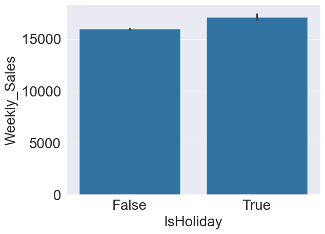

```python
sns.barplot(x='IsHoliday', y='Weekly_Sales', data=df)
```

```python
# Averiguemos cuantas fechas festivas estamos considerando

df_holiday = df.loc[df['IsHoliday']==True]
df_holiday['Date'].unique()
```

```
array(['2010-02-12', '2010-09-10', '2010-11-26', '2010-12-31',
       '2011-02-11', '2011-09-09', '2011-11-25', '2011-12-30',
       '2012-02-10', '2012-09-07'], dtype=object)
```

Ahora sabemos que tenemos las fechas festivas 2010-02-12 ⇒ Super Bowl 2010-09-10 ⇒ Labor Day 2010-11-26 ⇒ Thanksgiving 2010-12-31 ⇒ Christmas 2011-02-11 ⇒ Super Bowl 2011-09-09 ⇒ Labor Day 2011-11-25 ⇒ Thanksgiving 2011-12-30 ⇒ Christmas 2012-02-10 ⇒ Super Bowl 2012-09-07 ⇒ Labor Day

Un dato interesante es observar la diferencia entre las ventas cuando existe alguna festividad y cuando no para poder comparar de manera equitativa las ventas, por lo cual generaremos nuevos datos para graficarlos y asi entenderlo de una manera mas intuitiva.

```python
# Super bowl
df.loc[(df['Date'] == '2010-02-12')|(df['Date'] == '2011-02-11')|(df['Date'] == '2012-02-10'),'Super_Bowl'] = True
df.loc[(df['Date'] != '2010-02-12')&(df['Date'] != '2011-02-11')&(df['Date'] != '2012-02-10'),'Super_Bowl'] = False
```

```python
# Labor day dates in train set
df.loc[(df['Date'] == '2010-09-10')|(df['Date'] == '2011-09-09')|(df['Date'] == '2012-09-07'),'Labor_Day'] = True
df.loc[(df['Date'] != '2010-09-10')&(df['Date'] != '2011-09-09')&(df['Date'] != '2012-09-07'),'Labor_Day'] = False
```

```python
# Thanksgiving dates in train set
df.loc[(df['Date'] == '2010-11-26')|(df['Date'] == '2011-11-25'),'Thanksgiving'] = True
df.loc[(df['Date'] != '2010-11-26')&(df['Date'] != '2011-11-25'),'Thanksgiving'] = False
```

```python
#Christmas dates in train set
df.loc[(df['Date'] == '2010-12-31')|(df['Date'] == '2011-12-30'),'Christmas'] = True
df.loc[(df['Date'] != '2010-12-31')&(df['Date'] != '2011-12-30'),'Christmas'] = False
```

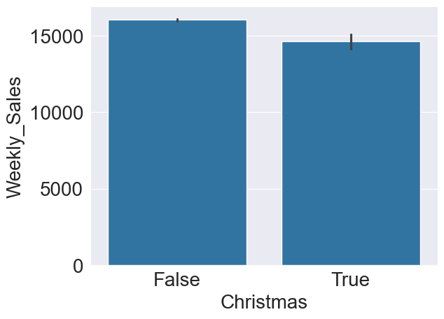

```python
sns.barplot(x='Christmas', y='Weekly_Sales', data=df) # Navidad vs no Navidad
```

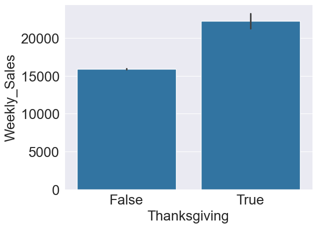

```python
sns.barplot(x='Thanksgiving', y='Weekly_Sales', data=df) # Thanksgiving holiday vs not-thanksgiving
```

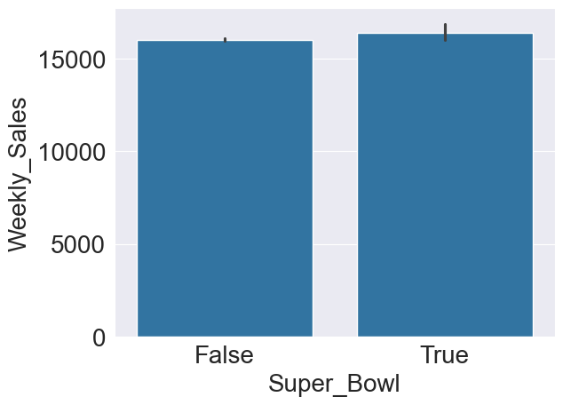

```python
sns.barplot(x='Super_Bowl', y='Weekly_Sales', data=df) # Super bowl holiday vs not-super bowl
```

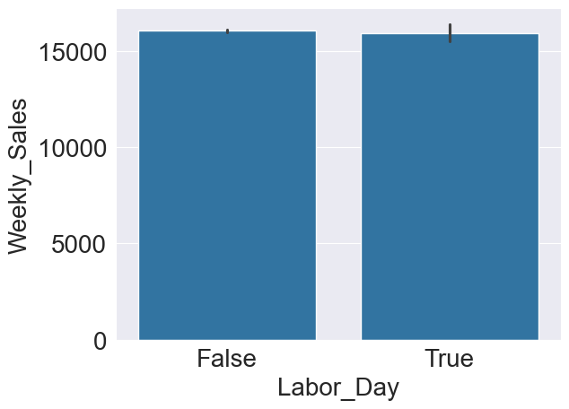

```python
sns.barplot(x='Labor_Day', y='Weekly_Sales', data=df) # Labor day holiday vs not-labor day
```

# Tipos de tiendas

Existen 3 tipos de tiendas, vale la pena saber el efecto que dichas tiendas causan en las ventas

```python
df.groupby(['Christmas','Type'])['Weekly_Sales'].mean()  # Avg weekly sales for types on Christmas
```

```
Christmas  Type
False      A       20174.350209
           B       12301.986116
           C        9570.951973
True       A       18310.167535
           B       11488.988057
           C        8031.520607
Name: Weekly_Sales, dtype: float64
```

```python
df.groupby(['Labor_Day','Type'])['Weekly_Sales'].mean()  # Avg weekly sales for types on Labor Day
```

```
Labor_Day  Type
False      A       20151.210941
           B       12294.954138
           C        9542.098293
True       A       20004.267422
           B       12084.304642
           C        9893.459258
Name: Weekly_Sales, dtype: float64
```

```python
df.groupby(['Thanksgiving','Type'])['Weekly_Sales'].mean()  # Avg weekly sales for types on Thanksgiving
```

```
Thanksgiving  Type
False         A       20044.007801
              B       12197.717405
              C        9547.377807
True          A       27397.776346
              B       18733.973971
              C        9696.566616
Name: Weekly_Sales, dtype: float64
```

```python
df.groupby(['Super_Bowl','Type'])['Weekly_Sales'].mean()  # Avg weekly sales for types on Super Bowl
```

```
Super_Bowl  Type
False       A       20138.055908
            B       12286.739293
            C        9536.110508
True        A       20612.757674
            B       12467.035506
            C       10179.271884
Name: Weekly_Sales, dtype: float64
```

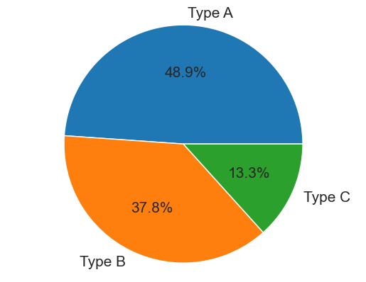

```python
my_data = [48.88, 37.77 , 13.33 ]  #percentages
my_labels = 'Type A','Type B', 'Type C' # labels
plt.pie(my_data,labels=my_labels,autopct='%1.1f%%', textprops={'fontsize': 15}) #plot pie type and bigger the labels
plt.axis('equal')
mpl.rcParams.update({'font.size': 20}) #bigger percentage labels

plt.show()
```

```python
df.groupby('IsHoliday')['Weekly_Sales'].mean()
```

```
IsHoliday
False    15952.816352
True     17094.300918
Name: Weekly_Sales, dtype: float64
```

```python
import seaborn as sns
sns.set_style("darkgrid")
```

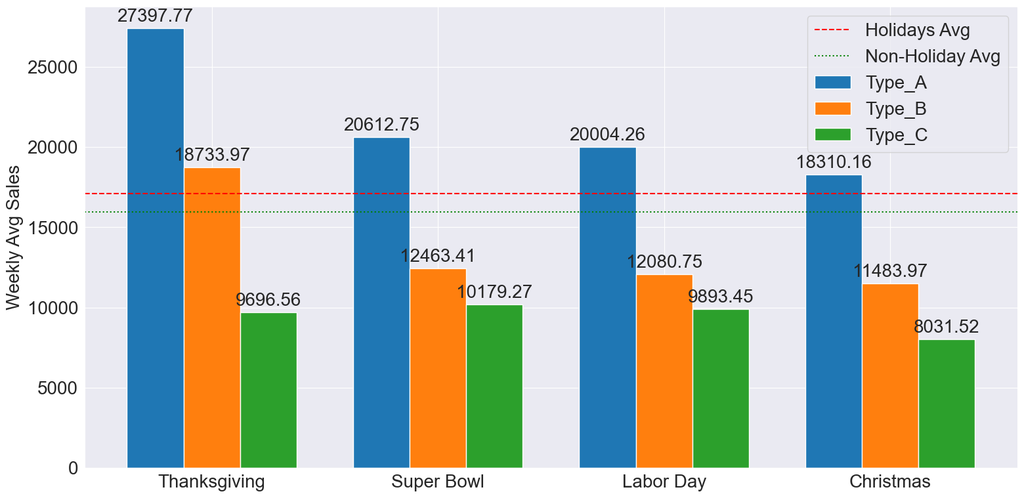

```python
 #Plotting avg wekkly sales according to holidays by types
import numpy as np
import matplotlib.pyplot as plt

sns.set_style("darkgrid")  # Configurar fondo

labels = ['Thanksgiving', 'Super Bowl', 'Labor Day', 'Christmas']
A_means = [27397.77, 20612.75, 20004.26, 18310.16]
B_means = [18733.97, 12463.41, 12080.75, 11483.97]
C_means = [9696.56, 10179.27, 9893.45, 8031.52]

x = np.arange(len(labels))  # Ubicaciones de etiquetas
width = 0.25  # Ancho de las barras

fig, ax = plt.subplots(figsize=(16, 8))
rects1 = ax.bar(x - width, A_means, width, label='Type_A', color='#1f77b4')
rects2 = ax.bar(x, B_means, width, label='Type_B', color='#ff7f0e')
rects3 = ax.bar(x + width, C_means, width, label='Type_C', color='#2ca02c')

ax.set_ylabel('Weekly Avg Sales')
ax.set_xticks(x)
ax.set_xticklabels(labels)
ax.legend()

# Función para agregar etiquetas en las barras
def autolabel(rects):
    for rect in rects:
        height = rect.get_height()
        ax.annotate(f'{height:.2f}',
                    xy=(rect.get_x() + rect.get_width() / 2, height),
                    xytext=(0, 3),
                    textcoords="offset points",
                    ha='center', va='bottom')

autolabel(rects1)
autolabel(rects2)
autolabel(rects3)

plt.axhline(y=17094.30, color='r', linestyle='dashed', label='Holidays Avg')
plt.axhline(y=15952.82, color='green', linestyle='dotted', label='Non-Holiday Avg')

fig.tight_layout()
plt.legend()
plt.show()
```

# Analizar las ventas mas a fondo

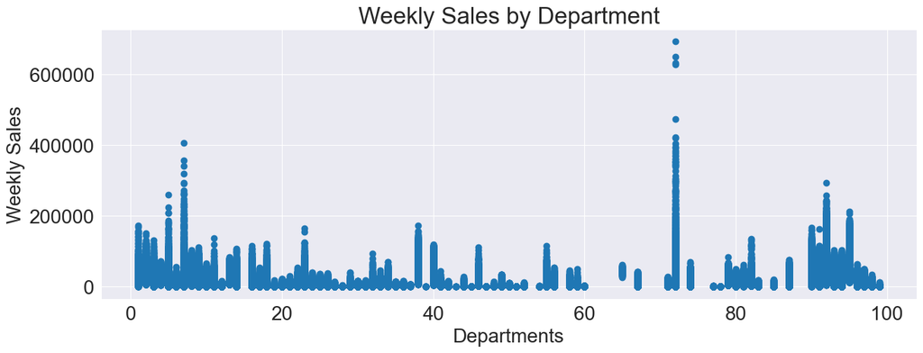

```python
x = df['Dept']
y = df['Weekly_Sales']
plt.figure(figsize=(15,5))
plt.title('Weekly Sales by Department')
plt.xlabel('Departments')
plt.ylabel('Weekly Sales')
plt.scatter(x,y)
plt.show()
```

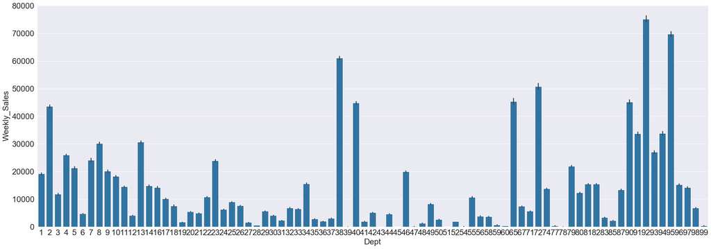

```python
plt.figure(figsize=(30,10))
fig = sns.barplot(x='Dept', y='Weekly_Sales', data=df)
```

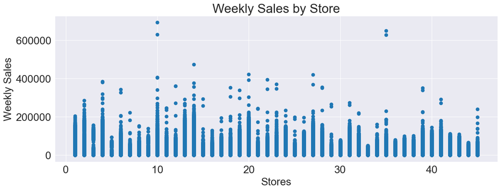

```python
x = df['Store']
y = df['Weekly_Sales']
plt.figure(figsize=(15,5))
plt.title('Weekly Sales by Store')
plt.xlabel('Stores')
plt.ylabel('Weekly Sales')
plt.scatter(x,y)
plt.show()
```

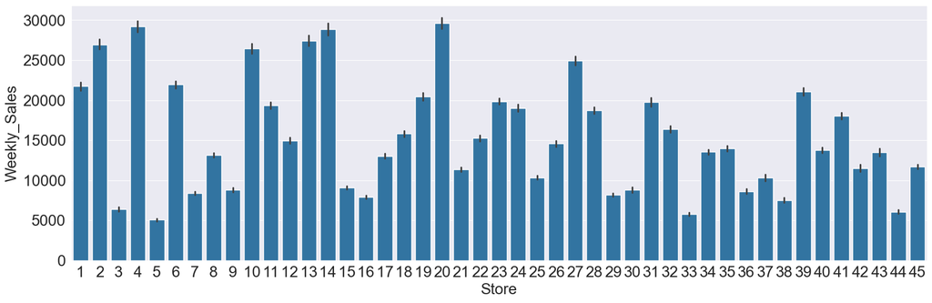

```python
plt.figure(figsize=(20,6))
fig = sns.barplot(x='Store', y='Weekly_Sales', data=df)
```